# Datenimport

Daten mit `{readr}`, `{readxl}` und `{haven}` in R einlesen

Autor:in

**EPFL Extension School**

# 1 📥 Die Daten einlesen

## Import: der erste Schritt der Pipeline

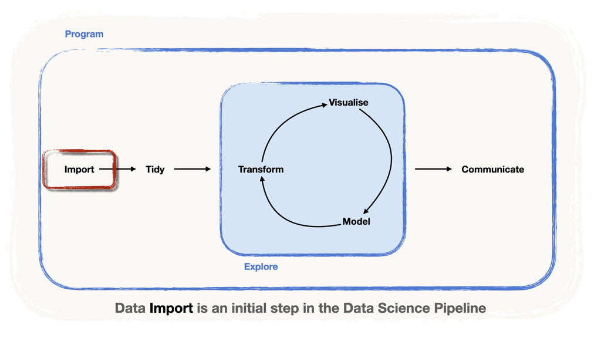

In der Data-Science-Pipeline beginnt jedes Data-Science-Projekt damit, **die Daten in unsere Software zu bringen**. Dieser Schritt heisst **Datenimport**.

## In dieser Einheit

In dieser Einheit zeigen wir, **wie man Daten in R einliest**:

- Wir betrachten **zwei besondere Fälle**: Dateien *mit Trennzeichen* und *MS-Excel-Arbeitsmappen*. Beide sind Beispiele für **tabellarische Daten**, also Daten in Tabellenform.
- Wir sprechen einige **Stolpersteine** an und zeigen die **Argumente** der Importfunktionen, mit denen sie sich umgehen lassen.
- Wir zeigen auch, wie man **andere Dateitypen importiert**, nämlich Dateien aus Statistiksoftware.

**HinweisHinweis**

Ein Teil der Daten in dieser Einheit ist simuliert.

# 2 📄 Dateien mit Trennzeichen

## Eine Tabelle in einer Textdatei

In Dateien mit Trennzeichen sind die Datensätze als **Tabelle** in einer **Textdatei** gespeichert: eine Tabellenzeile pro Textzeile, wobei die Spalten durch ein bestimmtes **Trennzeichen** getrennt sind, z. B. ein Komma (`,`), ein Semikolon (`;`) oder ein Tabulatorzeichen (kurz Tab).

Die Trennzeichen geben den beiden verbreitetsten Dateitypen ihre **Namen**: CSV (**C**omma-**S**eparated **V**alues, durch Kommas getrennte Werte, z. B. `data.csv`) und TSV (**T**ab-**S**eparated **V**alues, durch Tabulatoren getrennte Werte, z. B. `data.tsv`).

[figure not shown]

## Das CSV-Format

CSV-Dateien sind das **häufigste Dateiformat zum Austausch von Daten**. Sie können **Daten jeder Grösse** speichern, von klein bis zu mehreren GB. Ihr Hauptvorteil ist, dass sie **software-unabhängig** sind: Jedes Programm kann sie lesen. Das ist besonders nützlich, wenn Sie im Team arbeiten.

## `read_csv()` liest eine CSV-Datei in R ein

R hat Dutzende von Funktionen, um solche Dateien zu importieren. Wir verwenden die Funktionen des Pakets `{readr}`, das Teil des `{tidyverse}` ist. Die Funktion `read_csv()` liest CSV-Dateien.

Wir müssen ihr den **Pfad zur Datei** angeben, auf unserem Computer oder sogar im Web. Es ist praktisch, **die Daten in einem Objekt zu speichern**, damit wir sie später verwenden können:

```r
name_of_object <- read_csv("pfad_zur_datei")
```

## Beispiel: `team.csv` einlesen

Im Ordner `data` liegt eine Datei namens `team.csv`. Öffnen Sie sie zuerst, um sie anzuschauen:

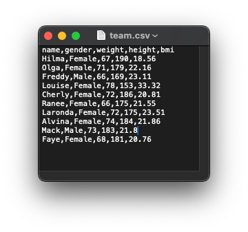

In unserem Fall lautet der Pfad, den wir `read_csv()` übergeben, `"data/team.csv"`. Wir speichern das Ergebnis im Objekt `team` und geben es aus, um es anzuschauen:

```r
# readr laden
library(readr)

# die Daten einlesen
team <- read_csv("data/team.csv")

# die Daten ausgeben
team
```

| name | gender | weight | height | bmi |
| --- | --- | --- | --- | --- |
| Hilma | Female | 67 | 190 | 18.56 |
| Olga | Female | 71 | 179 | 22.16 |
| Freddy | Male | 66 | 169 | 23.11 |
| Louise | Female | 78 | 153 | 33.32 |
| Cherly | Female | 72 | 186 | 20.81 |
| Ranee | Female | 66 | 175 | 21.55 |
| Laronda | Female | 72 | 175 | 23.51 |
| Alvina | Female | 74 | 184 | 21.86 |
| Mack | Male | 73 | 183 | 21.80 |
| Faye | Female | 68 | 181 | 20.76 |

# 3 Einige nützliche Argumente von `read_csv()`

## Wo Ihre Datei liegt: der Pfad `file`

Das erste Argument von `read_csv()` ist der Pfad zu der Datei, die Sie importieren möchten: *Wo, auf Ihrem Computer oder anderswo, liegt sie?* Das Argument heisst `file`. Der Pfad wird **als String** (Zeichenkette) angegeben und kann ein lokaler Pfad (`"data/team.csv"`) oder eine URL sein.

**TippRelative und absolute Pfade**

In Quarto- und R-Markdown-Dokumenten können Pfade im **Ordner des Dokuments** beginnen. Unser Dokument liegt in einem Ordner, der einen Ordner `data` enthält, in dem sich die Datei `team.csv` befindet:

- ✅ der **relative** Pfad `"data/team.csv"`
- ❌ ein **absoluter** Pfad wie `"/Users/jack/Documents/my/unique/folders/data/team.csv"`

Relative Pfade funktionieren auf **jedem Computer**, Sie können den Ordner also so weitergeben, wie er ist. Das ist äusserst hilfreich, besonders wenn Sie **mit anderen zusammenarbeiten!** Derselbe Code läuft auf deren Computer, unabhängig von ihrer Ordnerstruktur.

**Warnung**

Pfade beginnen **nur in Quarto- und R-Markdown-Dokumenten** im Ordner des Dokuments. In R-Skripten und in der Console beginnen sie stattdessen im *Arbeitsverzeichnis* (working directory).

## Auch CSV-/TSV-Daten können unordentlich sein!

Echte Dateien sehen selten so sauber aus wie `team.csv`. Ihnen kann die Kopfzeile fehlen, sie schreiben fehlende Werte auf ihre eigene Art, oder sie beginnen mit einigen Notizzeilen:

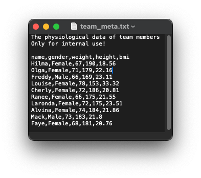

`read_csv()` hat für jeden dieser Stolpersteine ein Argument:

[figure not shown]

## Wenn die erste Zeile Daten enthält: `col_names = FALSE`

Manche Daten haben **keine Spaltennamen**. Die Datei `team_wo_header.csv` ist ein Beispiel dafür: Ihre erste Zeile enthält bereits Daten.

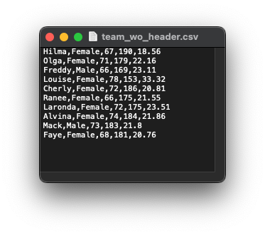

Standardmässig betrachtet `read_csv()` **die erste Zeile** als **Spaltennamen**, sodass das erste Teammitglied im Spaltenkopf landet:

```r
team_wo_header <- read_csv("data/team_wo_header.csv")

team_wo_header %>% head()
```

| Hilma | Female | 67 | 190 | 18.56 |
| --- | --- | --- | --- | --- |
| Olga | Female | 71 | 179 | 22.16 |
| Freddy | Male | 66 | 169 | 23.11 |
| Louise | Female | 78 | 153 | 33.32 |
| Cherly | Female | 72 | 186 | 20.81 |
| Ranee | Female | 66 | 175 | 21.55 |
| Laronda | Female | 72 | 175 | 23.51 |

Das Argument `col_names` legt fest, **wie die erste Zeile behandelt wird**: Enthält sie nicht die Spaltennamen, setzen wir `col_names = FALSE`, und R erzeugt die Spaltennamen `X1`, `X2` usw.

```r
team_wo_header <- read_csv("data/team_wo_header.csv",
                           col_names = FALSE)

team_wo_header %>% head()
```

| X1 | X2 | X3 | X4 | X5 |
| --- | --- | --- | --- | --- |
| Hilma | Female | 67 | 190 | 18.56 |
| Olga | Female | 71 | 179 | 22.16 |
| Freddy | Male | 66 | 169 | 23.11 |
| Louise | Female | 78 | 153 | 33.32 |
| Cherly | Female | 72 | 186 | 20.81 |
| Ranee | Female | 66 | 175 | 21.55 |

## Fehlende Werte angeben: `na = "null"`

In R werden **fehlende Werte als `NA` angegeben**. Andere Programme kennzeichnen einen fehlenden Wert jedoch auf andere Weise, z. B. mit `null`. Schauen Sie sich den Datensatz `team_missing.csv` an:

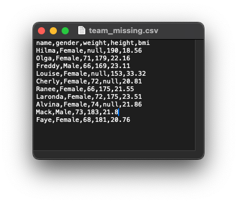

Beim Import mit `read_csv()` werden diese Werte als **Zeichenkette `"null"`** gelesen, und jede Spalte, die eine solche enthält, wird als Text importiert, auch wenn sie Zahlen enthält:

```r
team_missing <- read_csv("data/team_missing.csv")
team_missing
```

| name | gender | weight | height | bmi |
| --- | --- | --- | --- | --- |
| Hilma | Female | null | 190 | 18.56 |
| Olga | Female | 71 | 179 | 22.16 |
| Freddy | Male | 66 | 169 | 23.11 |
| Louise | Female | null | 153 | 33.32 |
| Cherly | Female | 72 | null | 20.81 |
| Ranee | Female | 66 | 175 | 21.55 |
| Laronda | Female | 72 | 175 | 23.51 |
| Alvina | Female | 74 | null | 21.86 |
| Mack | Male | 73 | 183 | 21.80 |
| Faye | Female | 68 | 181 | 20.76 |

Mit `na = "null"` ist das Problem gelöst: `null` wird als `NA` gelesen, und die numerischen Spalten sind wieder Zahlen.

```r
team_missing <- read_csv("data/team_missing.csv",
                         na = "null")
team_missing
```

| name | gender | weight | height | bmi |
| --- | --- | --- | --- | --- |
| Hilma | Female | NA | 190 | 18.56 |
| Olga | Female | 71 | 179 | 22.16 |
| Freddy | Male | 66 | 169 | 23.11 |
| Louise | Female | NA | 153 | 33.32 |
| Cherly | Female | 72 | NA | 20.81 |
| Ranee | Female | 66 | 175 | 21.55 |
| Laronda | Female | 72 | 175 | 23.51 |
| Alvina | Female | 74 | NA | 21.86 |
| Mack | Male | 73 | 183 | 21.80 |
| Faye | Female | 68 | 181 | 20.76 |

## Metadaten überspringen: `skip = 3`

Manche Textdateien enthalten in ihren ersten Zeilen eine **Beschreibung der Daten**, die man manchmal «Metadaten» nennt. Die Datei `team_meta.csv` beginnt mit drei solchen Zeilen: zwei Notizzeilen und einer leeren Zeile.

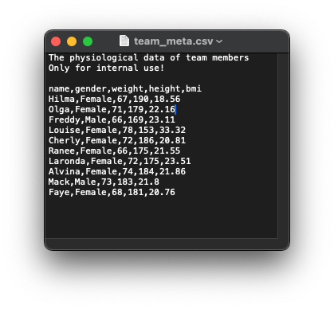

Liest man sie unverändert ein, geraten die Metadaten in die Daten:

```r
team_meta <- read_csv("data/team_meta.csv")
team_meta
```

| The physiological data of team members |
| --- |
| Only for internal use! |
| name,gender,weight,height,bmi |
| Hilma,Female,67,190,18.56 |
| Olga,Female,71,179,22.16 |
| Freddy,Male,66,169,23.11 |
| Louise,Female,78,153,33.32 |
| Cherly,Female,72,186,20.81 |
| Ranee,Female,66,175,21.55 |
| Laronda,Female,72,175,23.51 |
| Alvina,Female,74,184,21.86 |

[output cut: 2 more lines]

Beim Import in ein Tibble **müssen diese Zeilen übersprungen werden**. Das Argument `skip` gibt `read_csv()` an, wie viele Zeilen übersprungen werden:

```r
team_meta <- read_csv("data/team_meta.csv",
                      skip = 3)
team_meta
```

| name | gender | weight | height | bmi |
| --- | --- | --- | --- | --- |
| Hilma | Female | 67 | 190 | 18.56 |
| Olga | Female | 71 | 179 | 22.16 |
| Freddy | Male | 66 | 169 | 23.11 |
| Louise | Female | 78 | 153 | 33.32 |
| Cherly | Female | 72 | 186 | 20.81 |
| Ranee | Female | 66 | 175 | 21.55 |
| Laronda | Female | 72 | 175 | 23.51 |
| Alvina | Female | 74 | 184 | 21.86 |
| Mack | Male | 73 | 183 | 21.80 |
| Faye | Female | 68 | 181 | 20.76 |

## Sonderzeichen richtig lesen: `locale`

Dateien in einer **Sprache mit Sonderzeichen** (z. B. Französisch, Deutsch usw.) können verstümmelt ankommen, weil `read_csv()` die falsche **Zeichenkodierung** (encoding) errät. Die Datei `cities.csv` enthält zwei Schweizer Städtenamen:

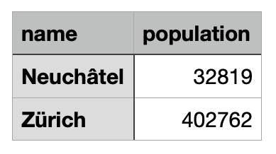

Vergleichen Sie die Ausgabe der folgenden Code-Chunks. Mit `locale = locale(encoding = "latin1")` wird die Datei mit der Kodierung `latin1` gelesen, sodass die Sonderzeichen korrekt importiert werden.

```r
cities <- read_csv("data/cities.csv")
cities
```

| name | population |
| --- | --- |
| Neuch\xe2tel | 32819 |
| Z\xfcrich | 402762 |

```r
cities <- read_csv(
  "data/cities.csv",
  locale = locale(encoding = "latin1"))
cities
```

| name | population |
| --- | --- |
| Neuchâtel | 32819 |
| Zürich | 402762 |

## 💡 Nutze die Macht `Tab`-Taste

**Tipp**

Wenn Sie den genauen Namen eines Arguments nicht mehr wissen, setzen Sie den Cursor zwischen die Klammern und drücken Sie `Tab`. Die Liste der Argumente der Funktion erscheint: Sie können das gewünschte auswählen und sogar eine kurze Beschreibung lesen.

## Andere Trennzeichen, dieselben Argumente

Da `read_csv()` ein Komma (`,`) als Trennzeichen verwendet, geht die Funktion davon aus, dass das **Dezimalzeichen ein Punkt (`.`)** ist. Sonst würde sie Dezimalzeichen mit Trennzeichen verwechseln!

- In Ländern mit **Dezimalkomma** ist das **Trennzeichen meist ein Semikolon (`;`)**. Für solche Dateien hat `read_csv()` einen Zwilling: `read_csv2()`.
- Zwei weitere Funktionen, `read_tsv()` und `read_delim()`, lesen tabulatorgetrennte Dateien und Dateien mit jedem anderen Trennzeichen.
- Ein weiterer Vorteil von `{readr}`: Alle Argumente, die wir gesehen haben, gibt es auch in diesen Funktionen.

Die folgende Tabelle fasst die Funktionen von `{readr}` und ihre Trennzeichen zusammen.

| Funktion | Trennzeichen | Standard-Dezimalzeichen |
| --- | --- | --- |
| `read_csv()` | `,` (Komma) | `.` (Punkt) |
| `read_csv2()` | `;` (Semikolon) | `,` (Komma) |
| `read_tsv()` | Tabulator | `.` (Punkt) |
| `read_delim()` | Beliebig | `.` (Punkt) |

# 4 📗 Excel-Dateien

## `{readxl}` liest Excel-Arbeitsmappen

MS Excel ist eines der beliebtesten Formate, um kleine Datensätze zu speichern. Schauen wir uns also an, **wie man Daten aus Excel-Dateien importiert**, die meist die Endung `.xls` oder `.xlsx` haben.

Wir verwenden das Paket `{readxl}`. Es wird zusammen mit dem `{tidyverse}` installiert, gehört aber nicht zu dessen Kern, sodass `library(tidyverse)` es nicht lädt. Falls es auf Ihrem System fehlt, installieren Sie es:

```r
install.packages("readxl")
```

**WarnungHinweis**

Auf Renku müssen Sie das nicht tun, das Paket ist bereits installiert!

Sobald es installiert ist, laden wir es:

```r
library(readxl)
```

Um Daten aus Excel in R einzulesen, hat `{readxl}` mehrere Funktionen. Wie bei `{readr}` ist das **erste Argument** der **Pfad** zur Datei.

| Funktion | Dateiendung |
| --- | --- |
| `read_xls()` | `.xls` |
| `read_xlsx()` | `.xlsx` |
| `read_excel()` | errät die Dateiendung |

## Beispiel: `team.xlsx` einlesen

Öffnen Sie die Datei `team.xlsx` (mit MS Excel) und schauen Sie sich an, wie sie aufgebaut ist:

[figure not shown]

Importieren wir sie dann in R und speichern ihren Inhalt im Objekt `team`:

```r
team <- read_xlsx("data/team.xlsx")
team
```

| name | gender | weight | height | bmi |
| --- | --- | --- | --- | --- |
| Hilma | Female | 62 | 184 | 18.31 |
| Olga | Female | 66 | 183 | 19.71 |
| Freddy | Male | 61 | 176 | 19.69 |
| Louise | Female | 73 | 155 | 30.39 |
| Cherly | Female | 67 | 181 | 20.45 |
| Ranee | Female | 61 | 174 | 20.15 |
| Laronda | Female | 67 | 173 | 22.39 |
| Alvina | Female | 69 | 160 | 26.95 |
| Mack | Male | 68 | 170 | 23.53 |
| Faye | Female | 63 | 179 | 19.66 |

[output cut: 10 more lines]

## Excel-Dateien sind noch unordentlicher!

Excel-Dateien sind nicht immer sauber und aufgeräumt. Öffnen Sie zum Beispiel die Datei `je-e-06.02.00.01.02.xlsx` und überzeugen Sie sich selbst: Es ist eine **Excel-Arbeitsmappe** mit mehreren **Blättern**, und die Tabelle steht irgendwo mitten in den **Zellen**.

[figure not shown]

Am Ende dieses Abschnitts können Sie die Daten, die Sie brauchen, aus dieser Datei herausholen. Diese Argumente verwenden wir dafür:

[figure not shown]

## Welches Blatt importieren: `sheet`

Eine Excel-Datei (eine Arbeitsmappe) kann mehrere **Blätter** (sheets) haben. Standardmässig importieren die Funktionen von `{readxl}` das **erste Blatt**. Das Argument **`sheet`** legt fest, **welches Blatt importiert wird**. Es kann als **Name des Blatts** angegeben werden, z. B. `sheet = "Women"`, oder als **seine Position** in der Arbeitsmappe, z. B. `sheet = 4`.

[figure not shown]

Importieren wir das Blatt `"Women"` aus `je-e-06.02.00.01.02.xlsx`:

```r
women_jobs <- read_xlsx("data/je-e-06.02.00.01.02.xlsx",
  sheet = "Women"
)

women_jobs %>% head()
```

| 06.02.00.01.02d Jobs by economic divisions | ...2 | ...3 | ...4 | ...5 | ...6 | ...7 | ...8 | ...9 | ...10 | ...11 | ...12 | ...13 | ...14 | ...15 | ...16 | ...17 | ...18 | ...19 | ...20 | ...21 | ...22 | ...23 | ...24 | ...25 | ...26 | ...27 | ...28 | ...29 | ...30 | … |
| --- | --- | --- | --- | --- | --- | --- | --- | --- | --- | --- | --- | --- | --- | --- | --- | --- | --- | --- | --- | --- | --- | --- | --- | --- | --- | --- | --- | --- | --- | --- |
| Full time and part time | NA | NA | NA | NA | NA | NA | NA | NA | NA | NA | NA | NA | NA | NA | NA | NA | NA | NA | NA | NA | NA | NA | NA | NA | NA | NA | NA | NA | NA | … |
| Women | NA | NA | NA | NA | NA | NA | NA | NA | NA | NA | NA | NA | NA | NA | NA | NA | NA | NA | NA | NA | NA | NA | NA | NA | NA | NA | NA | NA | NA | … |
| Quarterly values, in thousands | NA | NA | NA | NA | NA | NA | NA | NA | NA | NA | NA | NA | NA | NA | NA | NA | NA | NA | NA | NA | NA | NA | NA | NA | NA | NA | NA | NA | NA | … |
| NA | NA | NA | NA | NA | NA | NA | NA | NA | NA | NA | NA | NA | NA | NA | NA | NA | NA | NA | NA | NA | NA | NA | NA | NA | NA | NA | NA | NA | NA | … |
| Economic branches\r\n Sections and Divisions | NA | NA | 1991 | NA | 1992 | NA | NA | NA | 1993 | NA | NA | NA | 1994 | NA | NA | NA | 1995 | NA | NA | NA | 1996 | NA | NA | NA | 1997 | NA | NA | NA | 1998 | … |
| NA | NA | NA | III | IV | I | II | III | IV | I | II | III | IV | I | II | III | IV | I | II | III | IV | I | II | III | IV | I | II | III | IV | I | … |

**WichtigMoment!**

Die Daten sind importiert, aber noch nicht brauchbar.

## Welche Zellen importieren: `range`

Das Blatt anzugeben reicht hier nicht: Die Tabelle beginnt nicht oben links im Blatt, und die **Daten sind überall verteilt**, sodass das Überspringen von Zeilen (mit `skip`) nicht hilft. Ausserdem interessiert uns vielleicht nur ein Teil der Zellen.

Mit dem Argument `range` geben wir ein **Rechteck aus Zellen** über seine Zelle **oben links** und seine Zelle **unten rechts** an, getrennt durch einen Doppelpunkt (`:`). Zum Beispiel importiert `range = "B2:K14"` die Daten im Rechteck zwischen den Zellen B2 und K14. In unserer Datei liegt die Tabelle zwischen den Zellen A9 und DP72:

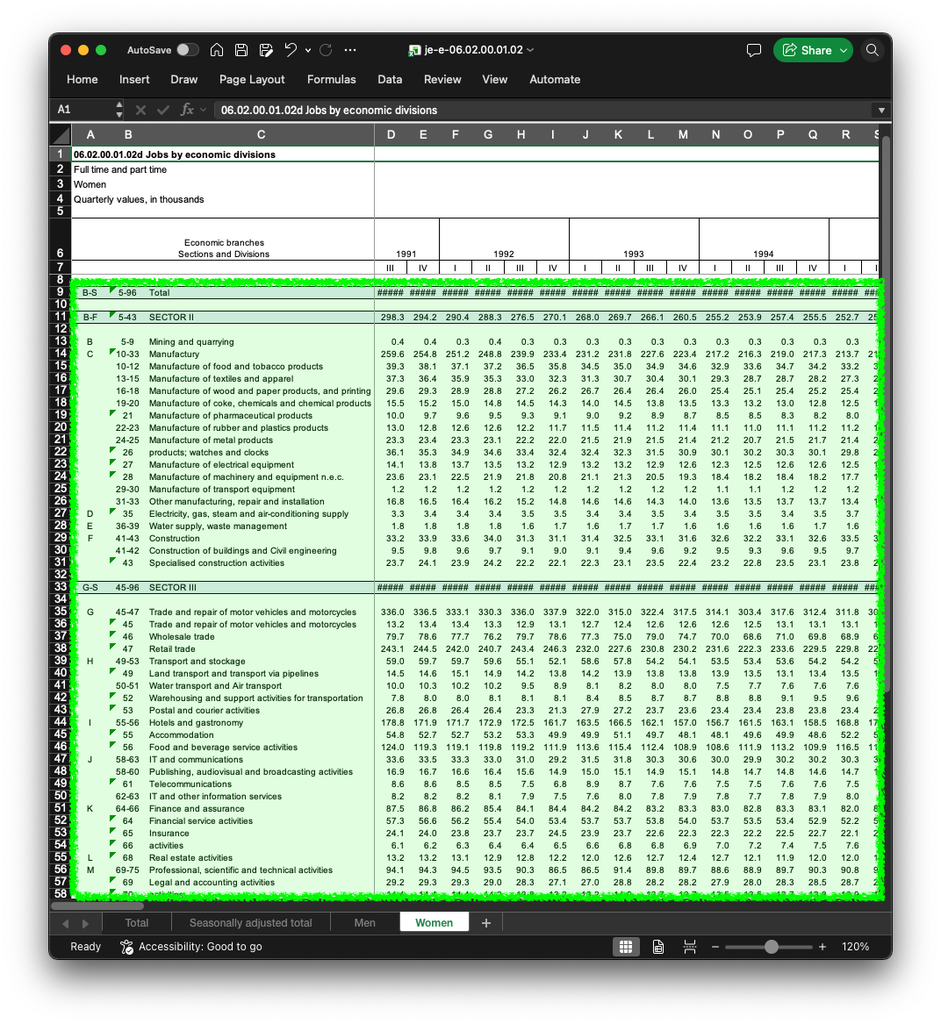

```r
women_jobs <- read_xlsx(
  "data/je-e-06.02.00.01.02.xlsx",
  sheet = "Women",
  range = "A9:DP72"
)

women_jobs
```

| B-S | 5-96 | Total | 1710064.5499 | 1704262.4754000001 | 1699109.2015 | 1696893.0288 | 1672964.4538 | 1638676.3631 | 1632557.2704 | 1644530.6231 | 1638546.6857 | 1628677.7028000001 | 1614918.9143000001 | 1609477.7178 | 1638743.5467000001 | 1630486.8839 | 1639813.3154 | 1636397.9375 | 1641207.1146 | 1632228.8348000001 | 1621344.7398000001 | 1630193.0596 | 1618614.4722 | 1623271.0473 | 1621275.5107 | 1629347.9480000001 | 1639733.9203999999 | 1630273.5474 | 1637161.3728 | … |
| --- | --- | --- | --- | --- | --- | --- | --- | --- | --- | --- | --- | --- | --- | --- | --- | --- | --- | --- | --- | --- | --- | --- | --- | --- | --- | --- | --- | --- | --- | --- |
| NA | NA | NA | NA | NA | NA | NA | NA | NA | NA | NA | NA | NA | NA | NA | NA | NA | NA | NA | NA | NA | NA | NA | NA | NA | NA | NA | NA | NA | NA | … |
| B-F | 5-43 | SECTOR II | 298283.3706 | 294159.2399 | 290407.3361 | 288324.2617 | 276505.2418 | 270076.3914 | 267969.3916 | 269700.8747 | 266149.4813 | 260463.9210 | 255203.2825 | 253927.0411 | 257426.4934 | 255454.2430 | 252736.3391 | 253098.8705 | 254603.1434 | 254393.5722 | 247854.7389 | 245021.9833 | 243487.4152 | 238639.9454 | 235235.3017 | 239185.8112 | 235871.1396 | 231021.0348 | 230843.7378 | … |
| NA | NA | NA | NA | NA | NA | NA | NA | NA | NA | NA | NA | NA | NA | NA | NA | NA | NA | NA | NA | NA | NA | NA | NA | NA | NA | NA | NA | NA | NA | … |
| B | 5-9 | Mining and quarrying | 353.1896 | 350.0771 | 345.0714 | 350.4776 | 344.8389 | 339.7659 | 333.5898 | 332.0632 | 322.9206 | 340.1451 | 329.9074 | 328.1033 | 329.6855 | 310.0699 | 319.2454 | 330.4898 | 338.4421 | 316.9576 | 316.2702 | 331.2633 | 316.2853 | 313.2617 | 322.5373 | 347.2429 | 363.7275 | 365.0619 | 385.5727 | … |
| C | 10-33 | Manufactury | 259642.5124 | 254771.2052 | 251216.8549 | 248766.9454 | 239879.8968 | 233441.2839 | 231170.8715 | 231791.8440 | 227571.0613 | 223405.7222 | 217159.9761 | 216266.5746 | 219008.9414 | 217325.9449 | 213654.3350 | 214452.5111 | 214634.6942 | 213622.9744 | 209468.1850 | 206637.1874 | 204983.3996 | 200961.0953 | 199272.9120 | 200336.4033 | 197456.0446 | 192868.6536 | 194001.5718 | … |
| NA | 10-12 | Manufacture of food and tobacco products | 39272.0226 | 38052.4793 | 37137.9797 | 37219.3040 | 36515.4732 | 35808.6983 | 34548.1874 | 35047.6993 | 34880.1037 | 34557.5936 | 32948.1078 | 33624.3665 | 34668.9149 | 34247.3476 | 33206.9601 | 33220.5229 | 33764.1389 | 33839.9025 | 32419.7936 | 32470.4169 | 32479.2125 | 31680.3308 | 30869.0123 | 31254.3267 | 31358.2006 | 30179.4300 | 29971.9298 | … |
| NA | 13-15 | Manufacture of textiles and apparel | 37265.9783 | 36377.2126 | 35894.3482 | 35274.7460 | 32978.4832 | 32278.8424 | 31335.2299 | 30726.3957 | 30424.7441 | 30129.7451 | 29280.0074 | 28716.4218 | 28742.8171 | 28214.8683 | 27317.3059 | 27217.6032 | 26121.0496 | 25990.1147 | 24919.0862 | 24554.0298 | 23816.9663 | 23585.1756 | 23388.0156 | 23187.9829 | 21962.9729 | 20832.8018 | 20925.2515 | … |
| NA | 16-18 | Manufacture of wood and paper products, and printing | 29553.3555 | 29280.0213 | 28933.6723 | 28845.1158 | 27212.3016 | 26234.1317 | 26719.5573 | 26428.9882 | 26441.9844 | 25979.8390 | 25418.1512 | 25105.4348 | 25427.7289 | 25239.7796 | 25358.1489 | 25510.5345 | 25646.7660 | 25706.5426 | 25093.4202 | 25296.4807 | 24520.1846 | 24863.2089 | 24561.9376 | 24128.9469 | 24131.3858 | 23447.9557 | 22791.6677 | … |
| NA | 19-20 | Manufacture of coke, chemicals and chemical products | 15547.3983 | 15172.8961 | 15049.2863 | 14801.6927 | 14530.3267 | 14301.2836 | 14030.3090 | 14452.8388 | 13830.4263 | 13490.0776 | 13283.6151 | 13169.9455 | 12993.6141 | 12792.9328 | 12533.9666 | 12496.0249 | 12597.5353 | 12254.0540 | 11937.4904 | 11634.5401 | 11660.4632 | 11171.1997 | 10931.9315 | 10991.1307 | 10326.5765 | 10137.7091 | 9961.6459 | … |
| NA | 21 | Manufacture of pharmaceutical products | 9953.0022 | 9719.0358 | 9630.2814 | 9480.9995 | 9299.3517 | 9104.6058 | 9016.3058 | 9214.1690 | 8904.1132 | 8689.5770 | 8540.0886 | 8454.1465 | 8329.2109 | 8205.3701 | 8045.0447 | 7992.6149 | 8064.7064 | 8004.6612 | 8021.4482 | 7959.7664 | 8142.2488 | 8004.5094 | 8030.4622 | 8178.2909 | 7977.0218 | 8040.1455 | 8080.4670 | … |

[output cut: 53 more lines]

**WichtigFast geschafft!**

Wir sind einen Schritt weiter, aber die **Spaltennamen enthalten Werte**.

## `col_names = FALSE` als Retter in der Not!

Im letzten Schritt setzen wir ein Argument, das wir bereits kennen: `col_names = FALSE`.

```r
women_jobs <- read_xlsx("data/je-e-06.02.00.01.02.xlsx",
  sheet = "Women",
  range = "A9:DP72",
  col_names = FALSE
)

women_jobs
```

| ...1 | ...2 | ...3 | ...4 | ...5 | ...6 | ...7 | ...8 | ...9 | ...10 | ...11 | ...12 | ...13 | ...14 | ...15 | ...16 | ...17 | ...18 | ...19 | ...20 | ...21 | ...22 | ...23 | ...24 | ...25 | ...26 | ...27 | ...28 | ...29 | ...30 | … |
| --- | --- | --- | --- | --- | --- | --- | --- | --- | --- | --- | --- | --- | --- | --- | --- | --- | --- | --- | --- | --- | --- | --- | --- | --- | --- | --- | --- | --- | --- | --- |
| B-S | 5-96 | Total | 1710064.5499 | 1704262.4754 | 1699109.2015 | 1696893.0288 | 1672964.4538 | 1638676.3631 | 1632557.2704 | 1644530.6231 | 1638546.6857 | 1628677.7028 | 1614918.9143 | 1609477.7178 | 1638743.5467 | 1630486.8839 | 1639813.3154 | 1636397.9375 | 1641207.1146 | 1632228.8348 | 1621344.7398 | 1630193.0596 | 1618614.4722 | 1623271.0473 | 1621275.5107 | 1629347.9480 | 1639733.9204 | 1630273.5474 | 1637161.3728 | … |
| NA | NA | NA | NA | NA | NA | NA | NA | NA | NA | NA | NA | NA | NA | NA | NA | NA | NA | NA | NA | NA | NA | NA | NA | NA | NA | NA | NA | NA | NA | … |
| B-F | 5-43 | SECTOR II | 298283.3706 | 294159.2399 | 290407.3361 | 288324.2617 | 276505.2418 | 270076.3914 | 267969.3916 | 269700.8747 | 266149.4813 | 260463.9210 | 255203.2825 | 253927.0411 | 257426.4934 | 255454.2430 | 252736.3391 | 253098.8705 | 254603.1434 | 254393.5722 | 247854.7389 | 245021.9833 | 243487.4152 | 238639.9454 | 235235.3017 | 239185.8112 | 235871.1396 | 231021.0348 | 230843.7378 | … |
| NA | NA | NA | NA | NA | NA | NA | NA | NA | NA | NA | NA | NA | NA | NA | NA | NA | NA | NA | NA | NA | NA | NA | NA | NA | NA | NA | NA | NA | NA | … |
| B | 5-9 | Mining and quarrying | 353.1896 | 350.0771 | 345.0714 | 350.4776 | 344.8389 | 339.7659 | 333.5898 | 332.0632 | 322.9206 | 340.1451 | 329.9074 | 328.1033 | 329.6855 | 310.0699 | 319.2454 | 330.4898 | 338.4421 | 316.9576 | 316.2702 | 331.2633 | 316.2853 | 313.2617 | 322.5373 | 347.2429 | 363.7275 | 365.0619 | 385.5727 | … |
| C | 10-33 | Manufactury | 259642.5124 | 254771.2052 | 251216.8549 | 248766.9454 | 239879.8968 | 233441.2839 | 231170.8715 | 231791.8440 | 227571.0613 | 223405.7222 | 217159.9761 | 216266.5746 | 219008.9414 | 217325.9449 | 213654.3350 | 214452.5111 | 214634.6942 | 213622.9744 | 209468.1850 | 206637.1874 | 204983.3996 | 200961.0953 | 199272.9120 | 200336.4033 | 197456.0446 | 192868.6536 | 194001.5718 | … |
| NA | 10-12 | Manufacture of food and tobacco products | 39272.0226 | 38052.4793 | 37137.9797 | 37219.3040 | 36515.4732 | 35808.6983 | 34548.1874 | 35047.6993 | 34880.1037 | 34557.5936 | 32948.1078 | 33624.3665 | 34668.9149 | 34247.3476 | 33206.9601 | 33220.5229 | 33764.1389 | 33839.9025 | 32419.7936 | 32470.4169 | 32479.2125 | 31680.3308 | 30869.0123 | 31254.3267 | 31358.2006 | 30179.4300 | 29971.9298 | … |
| NA | 13-15 | Manufacture of textiles and apparel | 37265.9783 | 36377.2126 | 35894.3482 | 35274.7460 | 32978.4832 | 32278.8424 | 31335.2299 | 30726.3957 | 30424.7441 | 30129.7451 | 29280.0074 | 28716.4218 | 28742.8171 | 28214.8683 | 27317.3059 | 27217.6032 | 26121.0496 | 25990.1147 | 24919.0862 | 24554.0298 | 23816.9663 | 23585.1756 | 23388.0156 | 23187.9829 | 21962.9729 | 20832.8018 | 20925.2515 | … |
| NA | 16-18 | Manufacture of wood and paper products, and printing | 29553.3555 | 29280.0213 | 28933.6723 | 28845.1158 | 27212.3016 | 26234.1317 | 26719.5573 | 26428.9882 | 26441.9844 | 25979.8390 | 25418.1512 | 25105.4348 | 25427.7289 | 25239.7796 | 25358.1489 | 25510.5345 | 25646.7660 | 25706.5426 | 25093.4202 | 25296.4807 | 24520.1846 | 24863.2089 | 24561.9376 | 24128.9469 | 24131.3858 | 23447.9557 | 22791.6677 | … |
| NA | 19-20 | Manufacture of coke, chemicals and chemical products | 15547.3983 | 15172.8961 | 15049.2863 | 14801.6927 | 14530.3267 | 14301.2836 | 14030.3090 | 14452.8388 | 13830.4263 | 13490.0776 | 13283.6151 | 13169.9455 | 12993.6141 | 12792.9328 | 12533.9666 | 12496.0249 | 12597.5353 | 12254.0540 | 11937.4904 | 11634.5401 | 11660.4632 | 11171.1997 | 10931.9315 | 10991.1307 | 10326.5765 | 10137.7091 | 9961.6459 | … |

[output cut: 54 more lines]

**WichtigAchten Sie auf die Namen**

Anders als `readr::read_csv()` benennt `{readxl}` die Spalten `...1`, `...2` usw.

# 5 📊 Dateien aus Statistiksoftware

## `{haven}` liest SAS-, SPSS- und Stata-Dateien

Daten können auch in einem Dateiformat vorliegen, das von Statistiksoftware wie SAS, SPSS oder Stata erzeugt wurde. Solche Daten lassen sich mit dem Paket `{haven}` importieren, das Dateien vom Typ `.sas7bdat`, `.sas7bcat`, `.xpt`, `.sav`, `.por` und `.dta` liest und schreibt.

Die folgende Tabelle fasst zusammen, welche Funktion Sie verwenden:

| Dateiendung | Software | Funktion |
| --- | --- | --- |
| `.sas7bdat` | SAS | `read_sas()` |
| `.sas7bcat` | SAS | `read_sas()` |
| `.xpt` | SAS | `read_xpt()` |
| `.sav` | SPSS | `read_sav()` |
| `.por` | SPSS | `read_por()` |
| `.dta` | Stata | `read_dta()` |

[figure not shown]

## Beispiel: eine SAS-Datei einlesen

Importieren wir zum Beispiel eine SAS-Datendatei mit `read_sas()`:

```r
library(haven)

mtcars_data <- read_sas("data/mtcars.sas7bdat")

mtcars_data
```

| mpg | cyl | disp | hp | drat | wt | qsec | vs | am | gear | carb |
| --- | --- | --- | --- | --- | --- | --- | --- | --- | --- | --- |
| 21.0 | 6 | 160.0 | 110 | 3.90 | 2.620 | 16.46 | 0 | 1 | 4 | 4 |
| 21.0 | 6 | 160.0 | 110 | 3.90 | 2.875 | 17.02 | 0 | 1 | 4 | 4 |
| 22.8 | 4 | 108.0 | 93 | 3.85 | 2.320 | 18.61 | 1 | 1 | 4 | 1 |
| 21.4 | 6 | 258.0 | 110 | 3.08 | 3.215 | 19.44 | 1 | 0 | 3 | 1 |
| 18.7 | 8 | 360.0 | 175 | 3.15 | 3.440 | 17.02 | 0 | 0 | 3 | 2 |
| 18.1 | 6 | 225.0 | 105 | 2.76 | 3.460 | 20.22 | 1 | 0 | 3 | 1 |
| 14.3 | 8 | 360.0 | 245 | 3.21 | 3.570 | 15.84 | 0 | 0 | 3 | 4 |
| 24.4 | 4 | 146.7 | 62 | 3.69 | 3.190 | 20.00 | 1 | 0 | 4 | 2 |
| 22.8 | 4 | 140.8 | 95 | 3.92 | 3.150 | 22.90 | 1 | 0 | 4 | 2 |
| 19.2 | 6 | 167.6 | 123 | 3.92 | 3.440 | 18.30 | 1 | 0 | 4 | 4 |

[output cut: 22 more lines]

Da diese Dateitypen sehr speziell sind, gehen wir nicht auf jedes einzelne Argument ein. Sie können aber jederzeit die Dokumentation lesen, z. B. `?read_sas`!

# 6 🧹 Spaltennamen bereinigen

Von Menschen erstellte Dateien haben oft unpraktische Spaltennamen: Leerzeichen, Grossbuchstaben, Einheiten in Klammern… Importieren wir ein kleines Beispiel, `team_bad_names.csv`. Um einen Namen wie `First Name` im Code zu verwenden, müssten wir ihn jedes Mal in Backticks setzen: `` team$`First Name` ``.

Die Funktion `clean_names()` aus dem Paket `{janitor}` **schreibt alle Spaltennamen** in Kleinbuchstaben im `snake_case` um:

```r
team <- read_csv("data/team_bad_names.csv")
team
```

| First Name | Passport gender | Weight (in kg) | Height (in cm) | Body Mass Index |
| --- | --- | --- | --- | --- |
| Hilma | Female | 67 | 190 | 18.56 |
| Olga | Female | 71 | 179 | 22.16 |
| Freddy | Male | 66 | 169 | 23.11 |
| Louise | Female | 78 | 153 | 33.32 |
| Cherly | Female | 72 | 186 | 20.81 |
| Ranee | Female | 66 | 175 | 21.55 |
| Laronda | Female | 72 | 175 | 23.51 |
| Alvina | Female | 74 | 184 | 21.86 |
| Mack | Male | 73 | 183 | 21.80 |
| Faye | Female | 68 | 181 | 20.76 |

```r
library(janitor)
team %>%
  clean_names()
```

| first_name | passport_gender | weight_in_kg | height_in_cm | body_mass_index |
| --- | --- | --- | --- | --- |
| Hilma | Female | 67 | 190 | 18.56 |
| Olga | Female | 71 | 179 | 22.16 |
| Freddy | Male | 66 | 169 | 23.11 |
| Louise | Female | 78 | 153 | 33.32 |
| Cherly | Female | 72 | 186 | 20.81 |
| Ranee | Female | 66 | 175 | 21.55 |
| Laronda | Female | 72 | 175 | 23.51 |
| Alvina | Female | 74 | 184 | 21.86 |
| Mack | Male | 73 | 183 | 21.80 |
| Faye | Female | 68 | 181 | 20.76 |

**TippWozu der Aufwand?**

Bereinigte Namen sind **schneller zu tippen** und **funktionieren ohne Backticks**, und RStudio kann sie **automatisch vervollständigen**. Rufen Sie `clean_names()` einmal auf, gleich nach dem Import, und der restliche Code bleibt einfach.

# 7 Übung

## Zeit für eine Übung!

**WichtigAn die Arbeit!**

Öffnen Sie das Übungs-Notebook `_exercises/exercise-notebook.qmd` und lösen Sie **Übung 1**. Bis gleich!